# irysy slides

## Cel analizy

Celem tej analizy było sprawdzenie, **które cechy fizyczne kwiatów Iris** pozwalają najlepiej rozróżnić trzy gatunki:

- *Iris setosa*
- *Iris versicolor*
- *Iris virginica*

Dataset zawiera **150 obserwacji** oraz **4 zmienne opisujące kształt kwiatu**:

| Cecha | Opis |
| --- | --- |
| Sepal length | Długość kielicha |
| Sepal width | Szerokość kielicha |
| Petal length | Długość płatka |
| Petal width | Szerokość płatka |

Badanie miało na celu **zrozumienie różnic między gatunkami** oraz ocenę, czy dane są stabilne i mogą zostać wykorzystane do modelowania.

### 🌸 Iris Setosa — najmniejsze płatki

**Setosa wyróżnia się najmniejszymi płatkami** — to najbardziej kompaktowy gatunek irysa, szczególnie pod względem **długości i szerokości płatka**.

Ta cecha powoduje, że *setosa* wyraźnie odróżnia się od pozostałych dwóch gatunków.

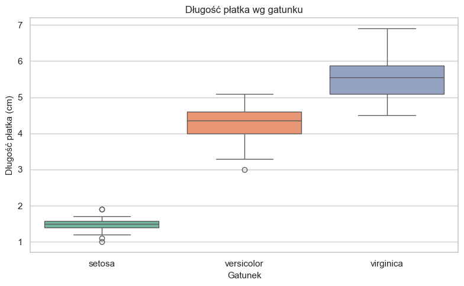

### 🌿 Iris Versicolor — cechy pośrednie

**Versicolor zajmuje pozycję pośrednią** między setosą a viriginicą pod względem rozmiaru płatków.

Widzimy, że:

- płatki są **większe niż u setosy**,
- ale **mniejsze niż u virginiki**,
- wartości układają się **wzdłuż przejścia** pomiędzy pozostałymi gatunkami.

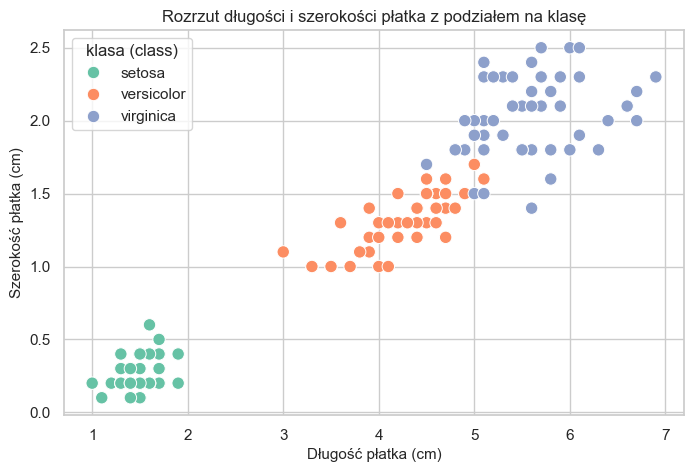

### 🌺 Iris Virginica — największe płatki

**Virginica** ma **największe płatki** (długość i szerokość), co mocno odróżnia ją od pozostałych gatunków.

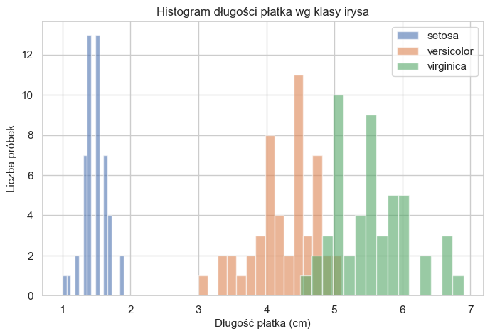

## Najważniejsze wnioski z analizy

### 🌸 Różnice między gatunkami

- **Setosa** wyróżnia się najmniejszymi płatkami (petal length, petal width)
- **Virginica** ma największe płatki — szczególnie szerokość płatka
- **Versicolor** zajmuje pozycję pośrednią między pozostałymi dwoma gatunkami

Te cechy pozwalają **wyraźnie oddzielić gatunki** w przestrzeni cech.

| klasa (class) | Śr. dł. płatka | Śr. szer. płatka | Śr. dł. kielicha |
| --- | --- | --- | --- |
| setosa | 1.460000 | 0.250000 | 5.010000 |
| versicolor | 4.260000 | 1.330000 | 5.940000 |
| virginica | 5.550000 | 2.030000 | 6.590000 |

### 🌱 Czy w danych są wartości odstające?

- W gatunku **setosa** pojawiają się pojedyncze kwiaty o nietypowej szerokości kielicha — jednak mieszczą się one w naturalnej zmienności.
- U **virginica** widać nieco większą różnorodność w szerokości płatków, co może wynikać z bardziej zróżnicowanej budowy tego gatunku.
- Pozostałe cechy są stabilne i układają się w bardzo czytelne wzorce między gatunkami.

✅ Nietypowe wartości są **nieliczne** i wyglądają na **naturalne różnice biologiczne**, a nie błędy pomiarowe.  
**Dane są czyste i nie wymagają dodatkowego przetwarzania przed modelowaniem.**

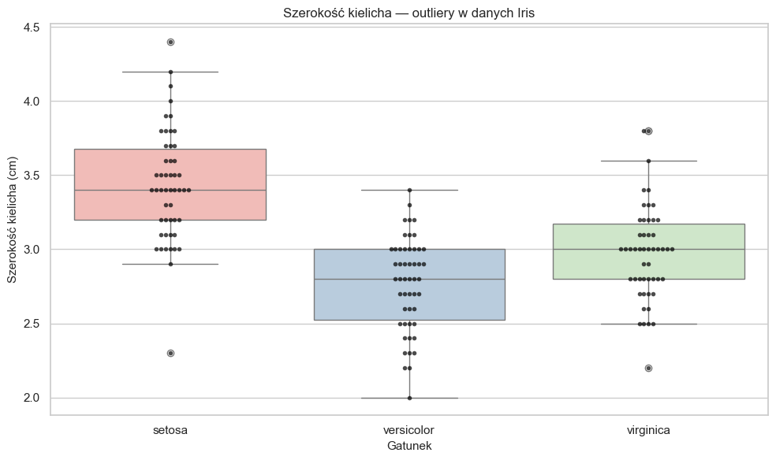

### Co wynika z tej analizy?

Dane o irysach pokazują, że **wystarczy kilka prostych pomiarów**, aby z dużą pewnością odróżnić gatunki roślin.  
Różnice są **wyraźne, naturalne biologicznie** i stabilne pomiędzy próbkami.

To sprawia, że zbiór Iris:

- jest **idealnym przykładem** do nauki klasyfikacji
- świetnie sprawdza się w edukacji i projektach ML
- pozwala zrozumieć, jak cechy wpływają na rozpoznawanie obiektów

### 🎯 Podsumowanie

- płatki → najważniejsza cecha odróżniająca gatunki
- dane są czyste i gotowe do modelowania
- irysy = świetny przykład klasyfikacji w biologii i ML